# Ford Go Bike Trip Data Exploration

## Introduction

This dataset contains durations and other features (including but not limited to user_type, member_birth_year, member_gender and bike_share_for_all_trip) for ford go bike trips in February 2019

## Preliminary Wrangling

```python
# import all packages and set plots to be embedded inline
import numpy as np
import pandas as pd
import matplotlib.pyplot as plt
import seaborn as sns

%matplotlib inline
```

```python
#Load the dataset
fordbike_df = pd.read_csv('201902-fordgobike-tripdata.csv')
```

```python
#View the head of the dataset
fordbike_df.head()
```

|  | duration_sec | start_time | end_time | start_station_id | start_station_name | start_station_latitude | start_station_longitude | end_station_id | end_station_name | end_station_latitude | end_station_longitude | bike_id | user_type | member_birth_year | member_gender | bike_share_for_all_trip |
| --- | --- | --- | --- | --- | --- | --- | --- | --- | --- | --- | --- | --- | --- | --- | --- | --- |
| 0 | 52185 | 2019-02-28 17:32:10.1450 | 2019-03-01 08:01:55.9750 | 21.0 | Montgomery St BART Station (Market St at 2nd St) | 37.789625 | -122.400811 | 13.0 | Commercial St at Montgomery St | 37.794231 | -122.402923 | 4902 | Customer | 1984.0 | Male | No |
| 1 | 42521 | 2019-02-28 18:53:21.7890 | 2019-03-01 06:42:03.0560 | 23.0 | The Embarcadero at Steuart St | 37.791464 | -122.391034 | 81.0 | Berry St at 4th St | 37.775880 | -122.393170 | 2535 | Customer | NaN | NaN | No |
| 2 | 61854 | 2019-02-28 12:13:13.2180 | 2019-03-01 05:24:08.1460 | 86.0 | Market St at Dolores St | 37.769305 | -122.426826 | 3.0 | Powell St BART Station (Market St at 4th St) | 37.786375 | -122.404904 | 5905 | Customer | 1972.0 | Male | No |
| 3 | 36490 | 2019-02-28 17:54:26.0100 | 2019-03-01 04:02:36.8420 | 375.0 | Grove St at Masonic Ave | 37.774836 | -122.446546 | 70.0 | Central Ave at Fell St | 37.773311 | -122.444293 | 6638 | Subscriber | 1989.0 | Other | No |
| 4 | 1585 | 2019-02-28 23:54:18.5490 | 2019-03-01 00:20:44.0740 | 7.0 | Frank H Ogawa Plaza | 37.804562 | -122.271738 | 222.0 | 10th Ave at E 15th St | 37.792714 | -122.248780 | 4898 | Subscriber | 1974.0 | Male | Yes |

```python
#View the datsets' shape
fordbike_df.shape
```

```
(183412, 16)
```

```python
#View the datasets' info
fordbike_df.info()
```

```
<class 'pandas.core.frame.DataFrame'>
RangeIndex: 183412 entries, 0 to 183411
Data columns (total 16 columns):
 #   Column                   Non-Null Count   Dtype
---  ------                   --------------   -----
 0   duration_sec             183412 non-null  int64
 1   start_time               183412 non-null  object
 2   end_time                 183412 non-null  object
 3   start_station_id         183215 non-null  float64
 4   start_station_name       183215 non-null  object
 5   start_station_latitude   183412 non-null  float64
 6   start_station_longitude  183412 non-null  float64
 7   end_station_id           183215 non-null  float64
 8   end_station_name         183215 non-null  object
 9   end_station_latitude     183412 non-null  float64
 10  end_station_longitude    183412 non-null  float64
 11  bike_id                  183412 non-null  int64
 12  user_type                183412 non-null  object
 13  member_birth_year        175147 non-null  float64
 14  member_gender            175147 non-null  object
 15  bike_share_for_all_trip  183412 non-null  object
dtypes: float64(7), int64(2), object(7)
memory usage: 22.4+ MB
```

```python
# Convert start_time and end_time to datetime objects
fordbike_df['start_time'] = pd.to_datetime(fordbike_df['start_time'])
fordbike_df['end_time'] = pd.to_datetime(fordbike_df['end_time'])

# Convert start_station_id and end_station_id to int datatypes
fordbike_df['start_station_id'] = fordbike_df['start_station_id'].astype('Int64')
fordbike_df['end_station_id'] = fordbike_df['end_station_id'].astype('Int64')

# Convert start_station_name, end_station_name, user_type, member_gender and bike_share_for_all_trip to category datatypes
fordbike_df['start_station_name'] = fordbike_df['start_station_name'].astype('category')
fordbike_df['end_station_name'] = fordbike_df['end_station_name'].astype('category')
fordbike_df['user_type'] = fordbike_df['user_type'].astype('category')
fordbike_df['member_gender'] = fordbike_df['member_gender'].astype('category')
fordbike_df['bike_share_for_all_trip'] = fordbike_df['bike_share_for_all_trip'].astype('category')
```

```python
#Viewing descriptice statistics for numerical variables/features
fordbike_df.describe()
```

|  | duration_sec | start_station_id | start_station_latitude | start_station_longitude | end_station_id | end_station_latitude | end_station_longitude | bike_id | member_birth_year |
| --- | --- | --- | --- | --- | --- | --- | --- | --- | --- |
| count | 183412.000000 | 183215.000000 | 183412.000000 | 183412.000000 | 183215.000000 | 183412.000000 | 183412.000000 | 183412.000000 | 175147.000000 |
| mean | 726.078435 | 138.590427 | 37.771223 | -122.352664 | 136.249123 | 37.771427 | -122.352250 | 4472.906375 | 1984.806437 |
| std | 1794.389780 | 111.778864 | 0.099581 | 0.117097 | 111.515131 | 0.099490 | 0.116673 | 1664.383394 | 10.116689 |
| min | 61.000000 | 3.000000 | 37.317298 | -122.453704 | 3.000000 | 37.317298 | -122.453704 | 11.000000 | 1878.000000 |
| 25% | 325.000000 | 47.000000 | 37.770083 | -122.412408 | 44.000000 | 37.770407 | -122.411726 | 3777.000000 | 1980.000000 |
| 50% | 514.000000 | 104.000000 | 37.780760 | -122.398285 | 100.000000 | 37.781010 | -122.398279 | 4958.000000 | 1987.000000 |
| 75% | 796.000000 | 239.000000 | 37.797280 | -122.286533 | 235.000000 | 37.797320 | -122.288045 | 5502.000000 | 1992.000000 |
| max | 85444.000000 | 398.000000 | 37.880222 | -121.874119 | 398.000000 | 37.880222 | -121.874119 | 6645.000000 | 2001.000000 |

```python
#Drop all null rows to enable visualizations plot properly
fordbike_df.drop(fordbike_df[fordbike_df.start_station_id.isnull()].index, inplace = True)
fordbike_df.drop(fordbike_df[fordbike_df.start_station_name.isnull()].index, inplace = True)
fordbike_df.drop(fordbike_df[fordbike_df.end_station_id.isnull()].index, inplace = True)
fordbike_df.drop(fordbike_df[fordbike_df.end_station_name.isnull()].index, inplace = True)
fordbike_df.drop(fordbike_df[fordbike_df.member_birth_year.isnull()].index, inplace = True)
fordbike_df.drop(fordbike_df[fordbike_df.member_gender.isnull()].index, inplace = True)
```

```python
#View the datasets' info
fordbike_df.info()
```

```
<class 'pandas.core.frame.DataFrame'>
Int64Index: 174952 entries, 0 to 183411
Data columns (total 16 columns):
 #   Column                   Non-Null Count   Dtype
---  ------                   --------------   -----
 0   duration_sec             174952 non-null  int64
 1   start_time               174952 non-null  datetime64[ns]
 2   end_time                 174952 non-null  datetime64[ns]
 3   start_station_id         174952 non-null  Int64
 4   start_station_name       174952 non-null  category
 5   start_station_latitude   174952 non-null  float64
 6   start_station_longitude  174952 non-null  float64
 7   end_station_id           174952 non-null  Int64
 8   end_station_name         174952 non-null  category
 9   end_station_latitude     174952 non-null  float64
 10  end_station_longitude    174952 non-null  float64
 11  bike_id                  174952 non-null  int64
 12  user_type                174952 non-null  category
 13  member_birth_year        174952 non-null  float64
 14  member_gender            174952 non-null  category
 15  bike_share_for_all_trip  174952 non-null  category
dtypes: Int64(2), category(5), datetime64[ns](2), float64(5), int64(2)
memory usage: 21.6 MB
```

### What is the structure of your dataset?

Some values have been set to categorical, some are integers or floats and some are datetime objects.

### What is/are the main feature(s) of interest in your dataset?

I am interested in finding out what feauture(s) determines the duration_sec of the trip

### What features in the dataset do you think will help support your investigation into your feature(s) of interest?

I think the member_birth_year will play a big part because younger people will be able to take longer rides, i also think the member_gender, user_type and bike_share_for_all_trip will play a part too.

## Univariate Exploration

Lets look at the distribution of the duration_sec plot

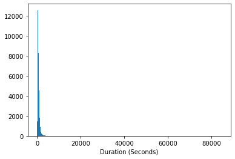

```python
#Standard plot of duration_sec

bin = np.arange(0, fordbike_df.duration_sec.max()+50, 50)
plt.hist(fordbike_df.duration_sec, bins = bin)
plt.xlabel('Duration (Seconds)');
```

The plot is long_tailed, lets use a log transformation for it

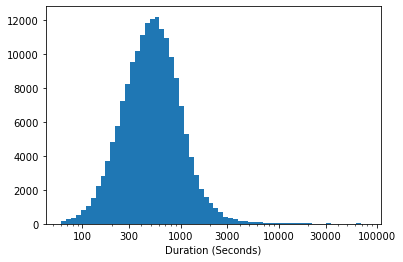

```python
#Log tranformed duration_sec histogram

bin = 10 ** np.arange(np.log10(fordbike_df.duration_sec.min()), np.log10(fordbike_df.duration_sec.max() + 0.05), 0.05)
plt.hist(fordbike_df.duration_sec, bins = bin)
plt.xscale('log')
plt.xlabel('Duration (Seconds)');
x_ticks = [100, 300, 1000, 3000, 10000, 30000, 100000]
xlabel = ['{}'.format(x) for x in x_ticks]
plt.xticks(x_ticks, xlabel);
```

The duration falls mostly between 300 and 1000 seconds, from this we can clearly see the length of the majority of the rides. We can also see that the distribution is unimodal.

Although it is weird for someone to have a trip of up to 85,000 seconds, i'll ignore this; taking in the condition that the person possibly forgot to return it or could had an extended trip

Then we will plot the member_birth_year column to see the distribution

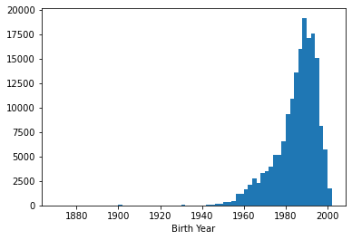

```python
#Standard plot of member_birth_year

bin = np.arange(1870, fordbike_df.member_birth_year.max()+2, 2)
plt.hist(fordbike_df.member_birth_year, bins = bin)
plt.xlabel('Birth Year');
```

We can see a leftly skewed plot, realistically someone born in 1880 will probably be dead; so we dig deeper

```python
#Finding everyone that was born before 1920
old_birth_year = fordbike_df[fordbike_df.member_birth_year < 1920]
old_birth_year.head(30)
```

|  | duration_sec | start_time | end_time | start_station_id | start_station_name | start_station_latitude | start_station_longitude | end_station_id | end_station_name | end_station_latitude | end_station_longitude | bike_id | user_type | member_birth_year | member_gender | bike_share_for_all_trip |
| --- | --- | --- | --- | --- | --- | --- | --- | --- | --- | --- | --- | --- | --- | --- | --- | --- |
| 1285 | 148 | 2019-02-28 19:29:17.627 | 2019-02-28 19:31:45.967 | 158 | Shattuck Ave at Telegraph Ave | 37.833279 | -122.263490 | 173 | Shattuck Ave at 55th St | 37.840364 | -122.264488 | 5391 | Subscriber | 1900.0 | Male | Yes |
| 10827 | 1315 | 2019-02-27 19:21:34.436 | 2019-02-27 19:43:30.008 | 343 | Bryant St at 2nd St | 37.783172 | -122.393572 | 375 | Grove St at Masonic Ave | 37.774836 | -122.446546 | 6249 | Subscriber | 1900.0 | Male | No |
| 16087 | 1131 | 2019-02-27 08:37:36.864 | 2019-02-27 08:56:28.022 | 375 | Grove St at Masonic Ave | 37.774836 | -122.446546 | 36 | Folsom St at 3rd St | 37.783830 | -122.398870 | 4968 | Subscriber | 1900.0 | Male | No |
| 19375 | 641 | 2019-02-26 17:03:19.855 | 2019-02-26 17:14:01.619 | 9 | Broadway at Battery St | 37.798572 | -122.400869 | 30 | San Francisco Caltrain (Townsend St at 4th St) | 37.776598 | -122.395282 | 6164 | Customer | 1900.0 | Male | No |
| 21424 | 1424 | 2019-02-26 08:58:02.904 | 2019-02-26 09:21:47.749 | 375 | Grove St at Masonic Ave | 37.774836 | -122.446546 | 343 | Bryant St at 2nd St | 37.783172 | -122.393572 | 5344 | Subscriber | 1900.0 | Male | No |
| 21506 | 701 | 2019-02-26 09:06:11.239 | 2019-02-26 09:17:52.442 | 67 | San Francisco Caltrain Station 2 (Townsend St... | 37.776639 | -122.395526 | 9 | Broadway at Battery St | 37.798572 | -122.400869 | 5337 | Customer | 1900.0 | Male | No |
| 24042 | 194 | 2019-02-25 18:58:10.644 | 2019-02-25 19:01:25.308 | 158 | Shattuck Ave at Telegraph Ave | 37.833279 | -122.263490 | 173 | Shattuck Ave at 55th St | 37.840364 | -122.264488 | 6363 | Subscriber | 1900.0 | Male | Yes |
| 26133 | 410 | 2019-02-25 13:38:12.067 | 2019-02-25 13:45:02.207 | 173 | Shattuck Ave at 55th St | 37.840364 | -122.264488 | 176 | MacArthur BART Station | 37.828410 | -122.266315 | 3311 | Subscriber | 1900.0 | Male | Yes |
| 27370 | 1474 | 2019-02-25 09:28:42.161 | 2019-02-25 09:53:17.068 | 15 | San Francisco Ferry Building (Harry Bridges Pl... | 37.795392 | -122.394203 | 386 | 24th St at Bartlett St | 37.752105 | -122.419724 | 6436 | Customer | 1878.0 | Female | No |
| 27675 | 1087 | 2019-02-25 09:10:39.549 | 2019-02-25 09:28:46.676 | 375 | Grove St at Masonic Ave | 37.774836 | -122.446546 | 36 | Folsom St at 3rd St | 37.783830 | -122.398870 | 5250 | Subscriber | 1900.0 | Male | No |
| 29716 | 403 | 2019-02-25 06:46:30.448 | 2019-02-25 06:53:13.914 | 284 | Yerba Buena Center for the Arts (Howard St at ... | 37.784872 | -122.400876 | 30 | San Francisco Caltrain (Townsend St at 4th St) | 37.776598 | -122.395282 | 3279 | Subscriber | 1901.0 | Male | No |
| 32285 | 299 | 2019-02-24 14:48:50.554 | 2019-02-24 14:53:50.330 | 179 | Telegraph Ave at 27th St | 37.816073 | -122.267886 | 195 | Bay Pl at Vernon St | 37.812314 | -122.260779 | 2339 | Subscriber | 1900.0 | Female | No |
| 32725 | 85 | 2019-02-24 13:49:52.142 | 2019-02-24 13:51:17.904 | 174 | Shattuck Ave at 51st St | 37.836801 | -122.264004 | 173 | Shattuck Ave at 55th St | 37.840364 | -122.264488 | 5176 | Subscriber | 1900.0 | Male | Yes |
| 32809 | 395 | 2019-02-24 13:32:43.034 | 2019-02-24 13:39:18.303 | 195 | Bay Pl at Vernon St | 37.812314 | -122.260779 | 179 | Telegraph Ave at 27th St | 37.816073 | -122.267886 | 2339 | Subscriber | 1900.0 | Female | No |
| 32942 | 169 | 2019-02-24 13:17:05.233 | 2019-02-24 13:19:54.375 | 173 | Shattuck Ave at 55th St | 37.840364 | -122.264488 | 174 | Shattuck Ave at 51st St | 37.836801 | -122.264004 | 5176 | Subscriber | 1900.0 | Male | Yes |
| 34747 | 180 | 2019-02-23 21:46:26.558 | 2019-02-23 21:49:26.839 | 174 | Shattuck Ave at 51st St | 37.836801 | -122.264004 | 204 | 55th St at Telegraph Ave | 37.840186 | -122.261822 | 5743 | Subscriber | 1900.0 | Male | Yes |
| 38932 | 389 | 2019-02-23 10:49:33.547 | 2019-02-23 10:56:03.428 | 173 | Shattuck Ave at 55th St | 37.840364 | -122.264488 | 150 | Adeline St at 40th St | 37.831277 | -122.278267 | 5435 | Subscriber | 1900.0 | Male | Yes |
| 41194 | 313 | 2019-02-22 18:55:09.207 | 2019-02-22 19:00:22.969 | 340 | Harmon St at Adeline St | 37.849735 | -122.270582 | 173 | Shattuck Ave at 55th St | 37.840364 | -122.264488 | 5619 | Subscriber | 1900.0 | Male | Yes |
| 41246 | 539 | 2019-02-22 18:46:15.403 | 2019-02-22 18:55:15.053 | 30 | San Francisco Caltrain (Townsend St at 4th St) | 37.776598 | -122.395282 | 25 | Howard St at 2nd St | 37.787522 | -122.397405 | 5859 | Subscriber | 1901.0 | Male | No |
| 41319 | 379 | 2019-02-22 18:43:07.018 | 2019-02-22 18:49:26.251 | 173 | Shattuck Ave at 55th St | 37.840364 | -122.264488 | 340 | Harmon St at Adeline St | 37.849735 | -122.270582 | 5699 | Subscriber | 1900.0 | Male | Yes |
| 43880 | 379 | 2019-02-22 15:58:02.725 | 2019-02-22 16:04:22.189 | 39 | Scott St at Golden Gate Ave | 37.778999 | -122.436861 | 74 | Laguna St at Hayes St | 37.776435 | -122.426244 | 4908 | Customer | 1900.0 | Male | No |
| 45846 | 1336 | 2019-02-22 10:53:45.889 | 2019-02-22 11:16:02.793 | 74 | Laguna St at Hayes St | 37.776435 | -122.426244 | 377 | Fell St at Stanyan St | 37.771917 | -122.453704 | 6193 | Customer | 1900.0 | Male | No |
| 48804 | 387 | 2019-02-22 07:01:50.431 | 2019-02-22 07:08:18.080 | 284 | Yerba Buena Center for the Arts (Howard St at ... | 37.784872 | -122.400876 | 30 | San Francisco Caltrain (Townsend St at 4th St) | 37.776598 | -122.395282 | 5157 | Subscriber | 1901.0 | Male | No |
| 58222 | 1055 | 2019-02-21 07:05:11.790 | 2019-02-21 07:22:47.591 | 375 | Grove St at Masonic Ave | 37.774836 | -122.446546 | 36 | Folsom St at 3rd St | 37.783830 | -122.398870 | 6101 | Subscriber | 1900.0 | Male | No |
| 60960 | 339 | 2019-02-20 18:08:14.886 | 2019-02-20 18:13:54.858 | 177 | MacArthur Blvd at Telegraph Ave | 37.826286 | -122.265100 | 173 | Shattuck Ave at 55th St | 37.840364 | -122.264488 | 5121 | Subscriber | 1900.0 | Male | Yes |
| 61611 | 87 | 2019-02-20 17:41:14.387 | 2019-02-20 17:42:41.909 | 176 | MacArthur BART Station | 37.828410 | -122.266315 | 177 | MacArthur Blvd at Telegraph Ave | 37.826286 | -122.265100 | 5121 | Subscriber | 1900.0 | Male | Yes |
| 62598 | 1420 | 2019-02-20 16:27:23.109 | 2019-02-20 16:51:03.781 | 343 | Bryant St at 2nd St | 37.783172 | -122.393572 | 375 | Grove St at Masonic Ave | 37.774836 | -122.446546 | 6335 | Subscriber | 1900.0 | Male | No |
| 66700 | 1157 | 2019-02-20 08:22:17.596 | 2019-02-20 08:41:35.430 | 375 | Grove St at Masonic Ave | 37.774836 | -122.446546 | 36 | Folsom St at 3rd St | 37.783830 | -122.398870 | 4413 | Subscriber | 1900.0 | Male | No |
| 72711 | 221 | 2019-02-19 15:58:18.804 | 2019-02-19 16:01:59.839 | 158 | Shattuck Ave at Telegraph Ave | 37.833279 | -122.263490 | 173 | Shattuck Ave at 55th St | 37.840364 | -122.264488 | 5167 | Subscriber | 1900.0 | Male | Yes |
| 72819 | 236 | 2019-02-19 15:41:13.029 | 2019-02-19 15:45:09.711 | 176 | MacArthur BART Station | 37.828410 | -122.266315 | 158 | Shattuck Ave at Telegraph Ave | 37.833279 | -122.263490 | 5167 | Subscriber | 1900.0 | Male | Yes |

There seems to be serveral people born in 1900 and 1901(Probably an Error) and 1 person born in 1878. Lets drop the rows with these values

```python
#Drop rows with birth years older than 1920

fordbike_df.drop(old_birth_year.index, inplace = True)
```

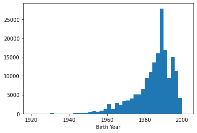

```python
#Log transformed plot of birth years

bin = 10 ** np.log10(np.arange(1920, fordbike_df.member_birth_year.max()+2, 2))
plt.hist(fordbike_df.member_birth_year, bins = bin)
plt.xscale('log')
x_scale= [1920, 1940, 1960, 1980, 2000]
xlabel = ['{}'.format(v) for v in x_scale]
plt.xticks(x_scale, xlabel)
plt.xlabel('Birth Year');
```

Lets also look at the Member Gender

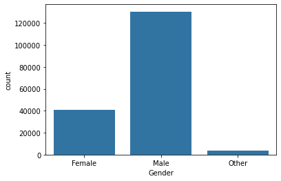

```python
#Standard bar chart for member_gender

base_color = sns.color_palette()[0]
sns.countplot(data = fordbike_df, x= 'member_gender', color = base_color)
plt.xlabel('Gender');
```

We can see that it is predominantly men that use the bikes, a few women and even less people who identify as other.

Let us look at the user_type

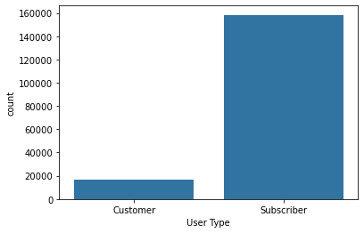

```python
#Standard bar chart for user_type

sns.countplot(data = fordbike_df, x= 'user_type', color = base_color)
plt.xlabel('User Type');
```

From this we can see that we have predominantly more subscribers using the bikes than customers

Lets look at whether the bikes were shared

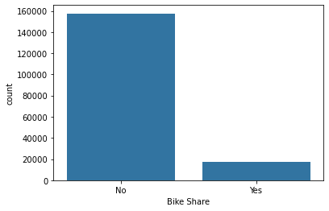

```python
#Standard bar chart for bike_share_for_all_trip

sns.countplot(data = fordbike_df, x= 'bike_share_for_all_trip', color = base_color)
plt.xlabel('Bike Share');
```

From this we can see that most of the bike rides are not shared

Lets also look at some other features in the dataset, i think finding out the start hours and end hours that have the most rides might show us some trends.

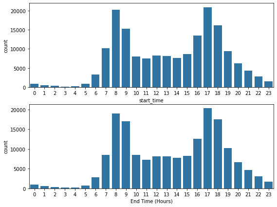

```python
fig, ax = plt.subplots(nrows  = 2, figsize = (9, 7))
sns.countplot(data = fordbike_df, x = fordbike_df.start_time.dt.hour, color = base_color, ax = ax[0])
plt.xlabel('Hours For Start Time')
sns.countplot(data = fordbike_df, x = fordbike_df.end_time.dt.hour, color = base_color, ax = ax[1])
plt.xlabel('End Time (Hours)')
plt.show();
```

From this we can see that peak hours are around 7 - 10 in the morning and 15 - 19 in the evening

### Of the features you investigated, were there any unusual distributions? Did you perform any operations on the data to tidy, adjust, or change the form of the data? If so, why did you do this?

Yes, in the member_birth_year plot i noticed that there was a great presence of outliers; there was even one with a year of 1878, i dropped the row because it is not feasible for someone born that year to ride a bicycle or even be alive

## Bivariate Exploration

Lets use the pairplot to see if any of the numerical values produce a correlation

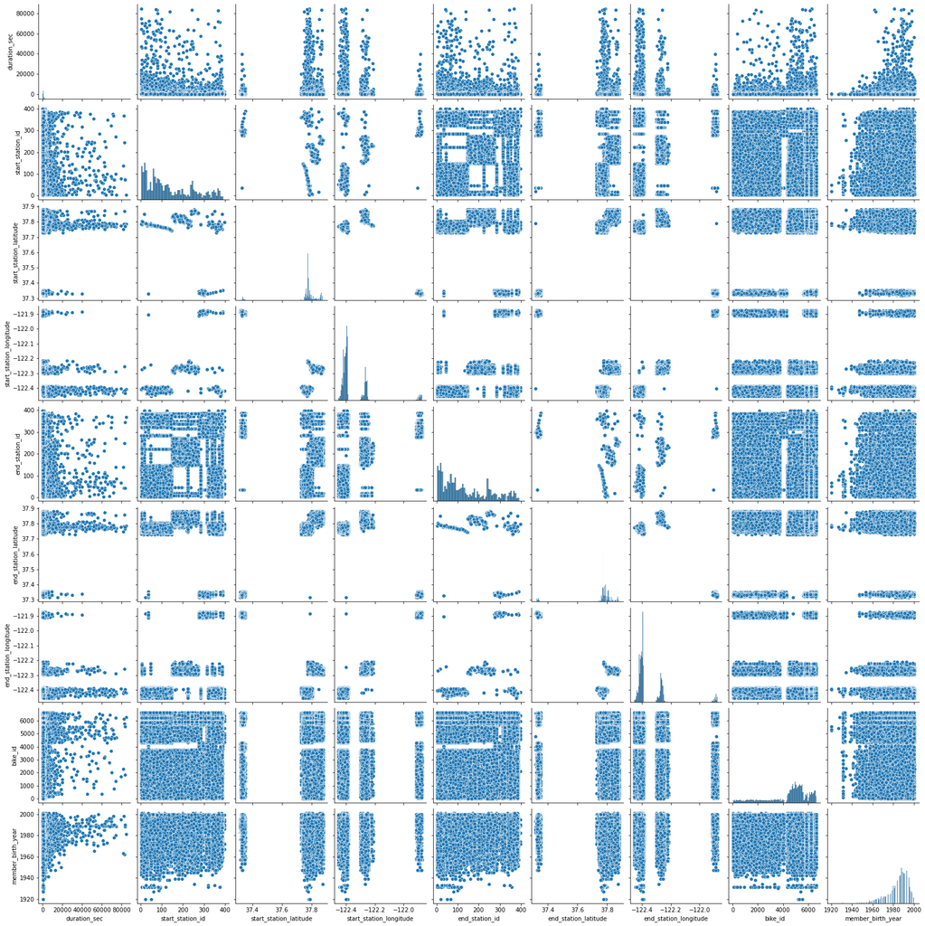

```python
#Correlation

sns.pairplot(fordbike_df)
```

From the above plot, we can see that the duration_sec and member_birth_year columns have a positive correlation

Lets Create a scatter plot to see this correlation better

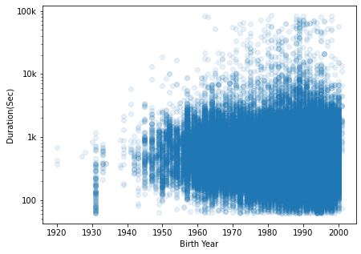

```python
#Log transformed plot to view correllation between member_birth_year and duration_sec

plt.figure(figsize =(7,5))
plt.scatter(data = fordbike_df, x = 'member_birth_year', y = 'duration_sec', alpha = 1/10)
plt.xlabel('Birth Year')
plt.ylabel('Duration(Sec)')
plt.yscale('log')
plt.yticks([100, 1000, 10000, 100000], ['100', '1k', '10k', '100k']);
```

Next, lets check if there is any trend between the hour a ride is started and the duration spent

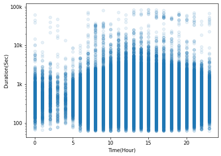

```python
#Log transformed plot to view correllation between Start_time(Hour) and duration_sec

plt.figure(figsize =(7,5))
plt.scatter(fordbike_df.start_time.dt.hour, fordbike_df.duration_sec, alpha = 1/10)
plt.xlabel('Time(Hour)')
plt.ylabel('Duration(Sec)')
plt.yscale('log')
plt.yticks([100, 1000, 10000, 100000], ['100', '1k', '10k', '100k']);
```

Lets look at the relationship between some other categorical variables and duration_sec, lets start with member_gender

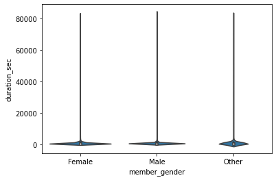

```python
#Lets use a violin plot to show the concentration the duration_sec column for the member_gender

sns.violinplot(data = fordbike_df, x = 'member_gender', y = 'duration_sec', color = base_color)
```

Although the plot does not show exactly where the data falls, we can see that majority of the data falls around 0 to 20000 seconds. Lets plot a log transformed boxplot to eliminate some of the outliers.

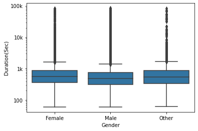

```python
#Lets use a log transformed boxplot to show the concentration the duration_sec column for the member_gender

sns.boxplot(data = fordbike_df, x = 'member_gender', y = 'duration_sec', color = base_color)
plt.xlabel('Gender')
plt.ylabel('Duration(Sec)')
plt.yscale('log')
plt.yticks([100, 1000, 10000, 100000], ['100', '1k', '10k', '100k']);
```

From the above plot, we can see better that the 'Female' gender has the longest rides, followed by other and then male.

Lets also compare the member_birth_year with the member_gender to see if we can discover any trends.

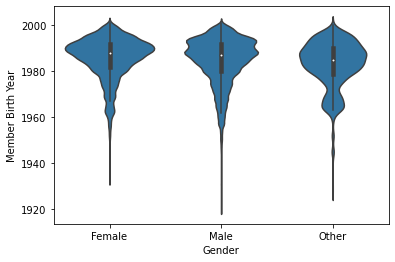

```python
#Violin plot of member_gender against member_birth_year

sns.violinplot(data = fordbike_df, x = 'member_gender', y = fordbike_df.member_birth_year, color = base_color);
plt.xlabel('Gender')
plt.ylabel('Member Birth Year')
```

From the above plot we can see that the concentration of birth years falls between 1980 to 2000. This follows the earlier trends we found when we plotted against the duration_sec column that there is a predominance of riders in this age gap.

We can slso see that the mid age falls around 1990. Lets plot the member gender against the hours to see if we can better tell their riding patterns with the hour start the ride

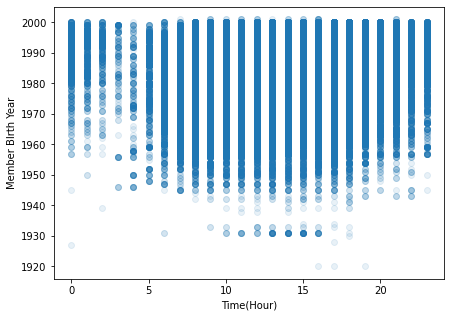

```python
#Scatter plot of member_birth_year against TIme
plt.figure(figsize =(7,5))
plt.scatter(fordbike_df.start_time.dt.hour, fordbike_df.member_birth_year, alpha = 1/10, color = base_color)
plt.xlabel('Time(Hour)')
plt.ylabel('Member BIrth Year');
```

Nothing New can really be seen from this plot, but this just affirms that most rides are started between 8 to 20 during the day. Though we can also see that much older people are most likely to ride during the day.

Lets go ahead and compare the user_type and duration_sec for more trends and insights.

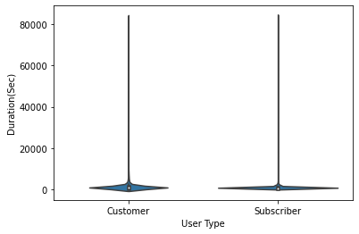

```python
#Violin plot of User_type and Duration_sec

sns.violinplot(data = fordbike_df, x = 'user_type', y = 'duration_sec', color = base_color)
plt.xlabel('User Type')
plt.ylabel('Duration(Sec)');
```

Once again, we can see an abundance of outliers, lets use a log transformed boxplot to see insights better

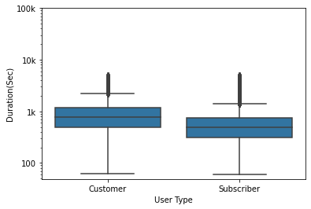

```python
#Log transformed boxplot of Duration_sec against user_type

sns.boxplot(data = duration_cut, x = 'user_type', y = 'duration_sec', color = base_color)
plt.xlabel('User Type')
plt.ylabel('Duration(Sec)')
plt.yscale('log')
plt.yticks([100, 1000, 10000, 100000], ['100', '1k', '10k', '100k']);
```

Although we saw earlier that we have way more subscribers that customers, we can see here that customers have relatively longer rides than subscribers.

Finally, lets compare the bike_share_for_all_trip and duration_sec column with a violinplot

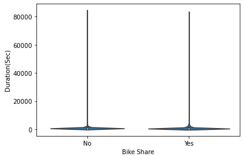

```python
#Violin plot of User_type and Duration_sec

sns.violinplot(data = fordbike_df, x = 'bike_share_for_all_trip', y = 'duration_sec', color = base_color)
plt.xlabel('Bike Share')
plt.ylabel('Duration(Sec)');
```

Once again, we can see that the plot is not clear so we use a log transformed box plot

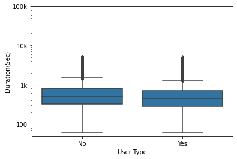

```python
#Log transformed boxplot of Duration_sec against bike_share_for_all_trip

sns.boxplot(data = duration_cut, x = 'bike_share_for_all_trip', y = 'duration_sec', color = base_color)
plt.xlabel('User Type')
plt.ylabel('Duration(Sec)')
plt.yscale('log')
plt.yticks([100, 1000, 10000, 100000], ['100', '1k', '10k', '100k']);
```

We can see that the No trips are longer.

### Talk about some of the relationships you observed in this part of the investigation. How did the feature(s) of interest vary with other features in the dataset?

In this part of the investigation i discovered that younger riders have longer rides that the older ones and a great amount of the very long rides are found with the youngest riders. I also discovered that the rides started between 8 to 12 are relatively longer than those at the other times at the day; although the longest rides in the dataset were found to have started between 13 and 17 in the day. Most of the rides are just about 0 to 3000 seconds long with a couple of them found lasting longer.

Another discovery found was also that customers have longer rides than subscibers, the difference between them is not really significant but there is a difference there (With customers having most rides between 500 to 1100 and subscibers between 300 to 800 seconds)

## Multivariate Exploration

Lets Firstly look at the relationship between the duration_sec, member_birth_year and member_gender. We had discovered that member_birth_year affects the duration_sec, lets find out if the member_gender column has any noticeable difference on this relationship

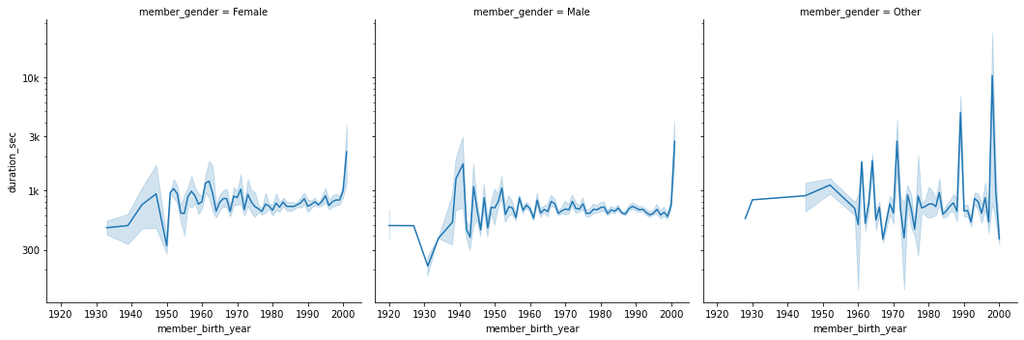

```python
#Log Transformed FacetGrid to compare duration_sec, member_birth_year and member_gender

g = sns.FacetGrid(data = fordbike_df, col = 'member_gender', height = 5)
g.map(sns.lineplot, 'member_birth_year', 'duration_sec')
plt.yscale('log')
plt.yticks([300, 1000, 3000, 10000], ['300', '1k', '3k', '10k']);
```

Lets see if the User_type has any effect just like member_gender has

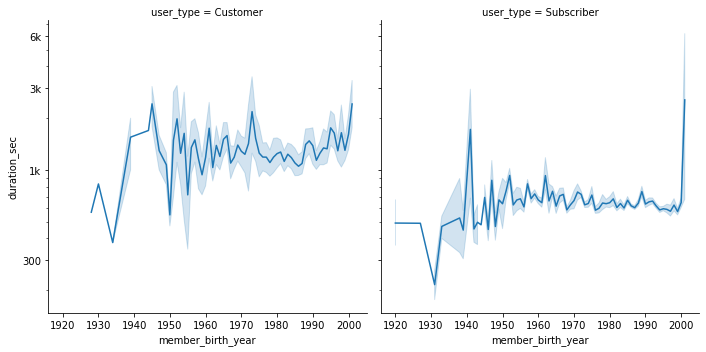

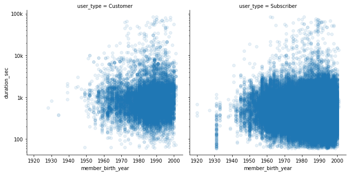

```python
#Log Transformed FacetGrid to compare duration_sec, member_birth_year and member_gender

g = sns.FacetGrid(data = fordbike_df, col = 'user_type', height = 5)
g.map(sns.lineplot, 'member_birth_year', 'duration_sec')
plt.yscale('log')
plt.yticks([300, 1000, 3000, 6000], ['300', '1k', '3k', '6k']);

g = sns.FacetGrid(data = fordbike_df, col = 'user_type', height = 5)
g.map(plt.scatter, 'member_birth_year', 'duration_sec', alpha = 1/10)
plt.yscale('log')
plt.yticks([100, 1000, 10000, 100000], ['100', '1k', '10k', '100k']);
```

From the plots above we can now see that the subscibers are generally older riders than the customers, we can also see that the younger customers have longer rides than the older customers and subsribers. With these plots we can see clearer than the boxplot and violinplot we used earlier.

We will compare the duration, gender and user type for more insights

```
C:\Users\newzion tt Ltd\anaconda3\lib\site-packages\seaborn\axisgrid.py:643: UserWarning: Using the boxplot function without specifying `order` is likely to produce an incorrect plot.
  warnings.warn(warning)
```

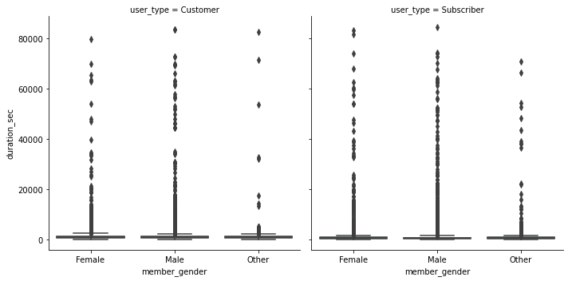

```python
g = sns.FacetGrid(data = fordbike_df, col = 'user_type', height = 5)
g.map(sns.boxplot, 'member_gender', 'duration_sec')
```

The values are not clear so we create a log transformed plot

```
C:\Users\newzion tt Ltd\anaconda3\lib\site-packages\seaborn\axisgrid.py:643: UserWarning: Using the boxplot function without specifying `order` is likely to produce an incorrect plot.
  warnings.warn(warning)
```

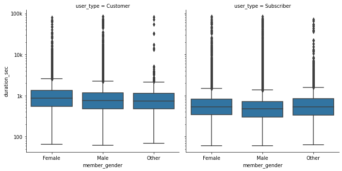

```python
#Log Transformed Facetgrid of Boxplots to compare member_gender, duration_sec and user_type

g = sns.FacetGrid(data = fordbike_df, col = 'user_type', height = 5 )
g.map(sns.boxplot, 'member_gender', 'duration_sec')
plt.yscale('log')

y_scale = [100, 1000, 10000, 100000]
ylabel = ['100', '1k', '10k', '100k']
plt.yticks(y_scale, ylabel);
```

Lets see if we can get any result when combining the values from the our first and second multivariate plots above, these are: duration_sec, member_birth_year, member_gender and user_type

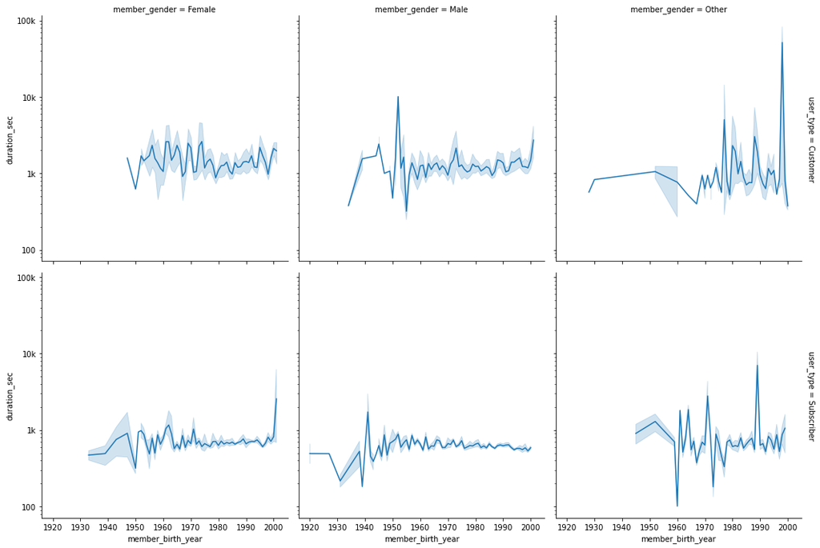

```python
#Log Transformed FacetGrid of lineplots to compare duration_sec, user_type, member_birth_year and member_gender

g = sns.FacetGrid(data = fordbike_df, col = 'member_gender', row = 'user_type', height = 5, margin_titles= True)
g.map(sns.lineplot, 'member_birth_year', 'duration_sec')
plt.yscale('log')

y_scale = [100, 1000, 10000, 100000]
ylabel = ['100', '1k', '10k', '100k']
plt.yticks(y_scale, ylabel);
```

We can see that the younger female customers born between 1980 and 2000 generally have the longest rides in the dataset. The plot above has really revealed a lot of insights on the dataset.

We earlier learnt that specific start times (Hours) have the longer rides, lets compare the duration_sec and member_birth_year for rides that start between those hours

```python
#Lets create a new dataset with the time limited to only 8 and 12, and add a new column hour

time_cut = fordbike_df[(fordbike_df.start_time.dt.hour >= 8) & (fordbike_df.start_time.dt.hour <= 12)]
time_cut.loc[:, 'hour'] = time_cut.start_time.dt.hour
```

[output not shown]

```
C:\Users\newzion tt Ltd\anaconda3\lib\site-packages\seaborn\axisgrid.py:316: UserWarning: The `size` parameter has been renamed to `height`; please update your code.
  warnings.warn(msg, UserWarning)
```

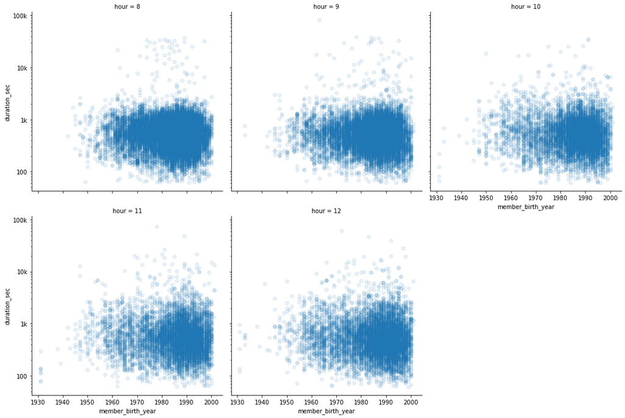

```python
#Log Transformed FacetGrid of scatterplots to compare duration_sec, user_type, member_birth_year and member_gender
#from the new time_cut dataset

g = sns.FacetGrid(data = time_cut, col = 'hour', size = 5, col_wrap= 3)
g.map(plt.scatter, 'member_birth_year', 'duration_sec', alpha = 1/10, color = base_color)
plt.yscale('log')
plt.yticks([100, 1000, 10000, 100000], ['100', '1k', '10k', '100k']);
```

From the plot above, we can't really see any outstanding trends

### Were there any interesting or surprising interactions between features?

Yes, i expected to see some relationships between start_time hour and other columns (apart from the target plot - duration_sec) but i did not see any. The only relationship i saw was with member_birth_year when i plotted the bivariate plots earlier.

## Conclusions

In summary, I have been able to come to the following conclusions:

From this research, I have concluded that the Member_gender, member_birth_year and the user_type columns all have a direct effect and impact on the duration of the ride. They either increase or decrease the length of the ride.